# Predictive analysis of Traffic collision risks

## DS1 : group 1

Realized by :

- Ghazi Ben Dahmen
- Oussama Ghdiri
- Wejdene Chandoul
- Wiem Sabbagh
- Achref Khemiri

### Problematic

In the last few years Artificial Intelligence has found its way to several fields of application of our daily life.

We found the idea very promising and with great potential for every single city in the world, if we could predict the number of accidents that are going to happen in a certain day , the authorities could deal with them a lot better .

Roger Thayne, former Chief Executive of the Staffordshire Ambulance Service has advised the BBC that potentially around 2,500 lives a year are being lost as a result of delayed ambulance response times and the inability to resuscitate patients at the scene. [source](https://www.clinicalnegligenceteam.co.uk/blog/deaths-due-to-ambulance-delays/)

### Business Objectives

- Identify what makes a commune more prone to accidents
- Prevent future deaths caused by ambulance delays

### Data Science goals

- realize a feature importance study on our model to tell what makes a commune have the most accidents
- predict number of future accidents

## Data preparation

We start by importing the needed libraries

- missingno for plotting missing data

```python
from fastai.imports import *
from fastai.structured import *
import missingno as msno
from tqdm import tqdm
%matplotlib inline
```

```python
lieux = pd.DataFrame()
usagers = pd.DataFrame()
vehicules = pd.DataFrame()
caracteristiques = pd.DataFrame()

def read_year(year):
    global lieux
    global usagers
    global vehicules
    global caracteristiques
    l = pd.read_csv(f'data/lieux-{year}.csv',encoding = "ISO-8859-1",low_memory=False)
    u = pd.read_csv(f'data/usagers-{year}.csv',encoding = "ISO-8859-1",low_memory=False)
    v = pd.read_csv(f'data/vehicules-{year}.csv',encoding = "ISO-8859-1",low_memory=False)
    c = pd.read_csv(f'data/caracteristiques-{year}.csv',encoding = "ISO-8859-1",low_memory=False)
    lieux = pd.concat([lieux,l],ignore_index=True)
    usagers = pd.concat([usagers,u],ignore_index=True)
    vehicules = pd.concat([vehicules,v],ignore_index=True)
    caracteristiques = pd.concat([caracteristiques,c],ignore_index=True)

for i in tqdm(range(2005,2017+1)):
    read_year(i)
```

```python
df = pd.merge(usagers,vehicules, on=["Num_Acc","num_veh"] ,how="inner")
df = pd.merge(df,lieux,on="Num_Acc",how="inner")
df = pd.merge(df,caracteristiques,on="Num_Acc",how="inner")
```

Let's check for missing data

```python
def missing_data(data):
    total = data.isnull().sum().sort_values(ascending = False)
    percent = (data.isnull().sum()/data.isnull().count()*100).sort_values(ascending = False)
    return pd.concat([total, percent], axis=1, keys=['Total NaN Values', 'Percentage of NaN Values'])
```

```python
missing_data(df)
```

|  | Total NaN Values | Percentage of NaN Values |
| --- | --- | --- |
| v2 | 1906963 | 95.733958 |
| v1 | 1242252 | 62.363927 |
| long | 1052629 | 52.844413 |
| lat | 1052619 | 52.843911 |
| gps | 1036333 | 52.026316 |
| pr1 | 984499 | 49.424129 |
| pr | 981434 | 49.270259 |
| adr | 336671 | 16.901664 |
| voie | 140254 | 7.041076 |
| place | 110298 | 5.537215 |
| secu | 51953 | 2.608161 |
| lartpc | 26058 | 1.308172 |
| larrout | 22788 | 1.144010 |
| env1 | 11589 | 0.581795 |
| infra | 11456 | 0.575118 |
| situ | 10443 | 0.524263 |
| vosp | 5056 | 0.253823 |
| nbv | 4973 | 0.249656 |
| plan | 4399 | 0.220840 |
| prof | 3399 | 0.170638 |
| surf | 3352 | 0.168278 |
| circ | 2611 | 0.131078 |
| an_nais | 2384 | 0.119682 |
| actp | 1745 | 0.087603 |
| etatp | 1705 | 0.085595 |
| locp | 1639 | 0.082282 |
| obs | 798 | 0.040061 |
| obsm | 701 | 0.035192 |
| trajet | 375 | 0.018826 |
| manv | 237 | 0.011898 |
| senc | 155 | 0.007781 |
| choc | 151 | 0.007581 |
| atm | 137 | 0.006878 |
| col | 35 | 0.001757 |
| com | 6 | 0.000301 |
| catr | 2 | 0.000100 |
| catu | 0 | 0.000000 |
| grav | 0 | 0.000000 |
| sexe | 0 | 0.000000 |
| dep | 0 | 0.000000 |
| num_veh | 0 | 0.000000 |
| catv | 0 | 0.000000 |
| occutc | 0 | 0.000000 |
| an | 0 | 0.000000 |
| mois | 0 | 0.000000 |
| jour | 0 | 0.000000 |
| hrmn | 0 | 0.000000 |
| lum | 0 | 0.000000 |
| agg | 0 | 0.000000 |
| int | 0 | 0.000000 |
| Num_Acc | 0 | 0.000000 |

It looks like we have quite a lot of missing data , especially in these ones

- adr : Postal address: variable filled in for accidents occurring in built-up areas
- gps : GPS coding: 1 originator character:
- lat : Latitude
- long : Longitude
- V1: Numeric index of the route number (example: 2 bis, 3 ter etc.)
- V2: Letter alphanumeric index of the road
- pr: Home PR number (upstream terminal number)
- pr1: Distance in meters to the PR (relative to the upstream terminal)

Luckily we can get rid of them since they don't seem that important ( adr , gps , lat and long are highly correlated to com and dep )

```python
df.dropna(subset=['com','dep'],inplace=True)
df.drop(['v2', 'v1', 'long', 'lat', 'pr1', 'pr', 'gps','adr'], axis = 1,inplace=True)
missing_data(df)
```

|  | Total NaN Values | Percentage of NaN Values |
| --- | --- | --- |
| voie | 140254 | 7.041097 |
| place | 110298 | 5.537232 |
| secu | 51953 | 2.608169 |
| lartpc | 26058 | 1.308176 |
| larrout | 22788 | 1.144014 |
| env1 | 11589 | 0.581796 |
| infra | 11456 | 0.575119 |
| situ | 10443 | 0.524264 |
| vosp | 5056 | 0.253824 |
| nbv | 4973 | 0.249657 |
| plan | 4399 | 0.220841 |
| prof | 3399 | 0.170638 |
| surf | 3352 | 0.168279 |
| circ | 2611 | 0.131079 |
| an_nais | 2384 | 0.119683 |
| actp | 1745 | 0.087603 |
| etatp | 1705 | 0.085595 |
| locp | 1639 | 0.082282 |
| obs | 798 | 0.040062 |
| obsm | 701 | 0.035192 |
| trajet | 375 | 0.018826 |
| manv | 237 | 0.011898 |
| senc | 155 | 0.007781 |
| choc | 151 | 0.007581 |
| atm | 137 | 0.006878 |
| col | 35 | 0.001757 |
| catr | 2 | 0.000100 |
| num_veh | 0 | 0.000000 |
| catu | 0 | 0.000000 |
| grav | 0 | 0.000000 |
| sexe | 0 | 0.000000 |
| dep | 0 | 0.000000 |
| catv | 0 | 0.000000 |
| occutc | 0 | 0.000000 |
| com | 0 | 0.000000 |
| an | 0 | 0.000000 |
| mois | 0 | 0.000000 |
| jour | 0 | 0.000000 |
| hrmn | 0 | 0.000000 |
| lum | 0 | 0.000000 |
| agg | 0 | 0.000000 |
| int | 0 | 0.000000 |
| Num_Acc | 0 | 0.000000 |

Let's graph the missing data using missingno :

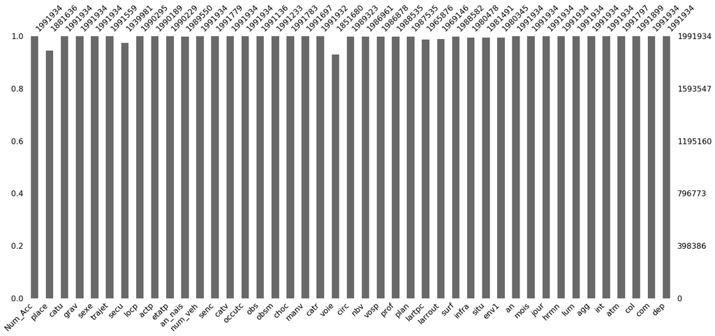

```python
msno.bar(df,sort="ascending")
```

Let's add some time information  
Day of week / day of year will be helpful for our data visualization  
and the date column will help us check if that day was a holiday or not

```python
df["hour"] = (df.hrmn - df.hrmn%100)/100
df["min"] = df.hrmn - df.hour*100;
df.an = df.an + 2000
df['date']= df.apply(lambda row :
                          datetime.date(row.an,row.mois,row.jour),
                          axis=1)
df['date'] = pd.to_datetime(df['date'])
df['day_of_week'] = df['date'].dt.dayofweek
df['day_of_year'] = df['date'].dt.dayofyear
df.head()
```

|  | Num_Acc | place | catu | grav | sexe | trajet | secu | locp | actp | etatp | ... | int | atm | col | com | dep | hour | min | date | day_of_week | day_of_year |
| --- | --- | --- | --- | --- | --- | --- | --- | --- | --- | --- | --- | --- | --- | --- | --- | --- | --- | --- | --- | --- | --- |
| 0 | 200500000001 | 1.0 | 1 | 4 | 1 | 1.0 | 11.0 | 0.0 | 0.0 | 0.0 | ... | 1 | 1.0 | 3.0 | 11.0 | 590 | 19.0 | 0.0 | 2005-01-12 | 2 | 12 |
| 1 | 200500000001 | 1.0 | 1 | 3 | 2 | 3.0 | 11.0 | 0.0 | 0.0 | 0.0 | ... | 1 | 1.0 | 3.0 | 11.0 | 590 | 19.0 | 0.0 | 2005-01-12 | 2 | 12 |
| 2 | 200500000001 | 2.0 | 2 | 1 | 1 | 0.0 | 11.0 | 0.0 | 0.0 | 0.0 | ... | 1 | 1.0 | 3.0 | 11.0 | 590 | 19.0 | 0.0 | 2005-01-12 | 2 | 12 |
| 3 | 200500000001 | 4.0 | 2 | 1 | 1 | 0.0 | 31.0 | 0.0 | 0.0 | 0.0 | ... | 1 | 1.0 | 3.0 | 11.0 | 590 | 19.0 | 0.0 | 2005-01-12 | 2 | 12 |
| 4 | 200500000001 | 5.0 | 2 | 1 | 1 | 0.0 | 11.0 | 0.0 | 0.0 | 0.0 | ... | 1 | 1.0 | 3.0 | 11.0 | 590 | 19.0 | 0.0 | 2005-01-12 | 2 | 12 |

5 rows × 48 columns

```python
df.to_csv('accidents.csv')
```

```python
df = pd.read_csv('accidents.csv',low_memory=False)
```

```python
df.com = df.com.astype(int).astype(str)
df.dep = df.dep.astype(str)
```

```python
df['commune'] = df.dep + df.com
```

We still have missing values for

- voie
- place
- secu
- lartpc
- larrout
- env1
- infra
- situ
- vosp
- nbv
- plan
- prof
- surf
- circ
- an_nais
- actp
- etatp
- locp
- obs
- obsm
- trajet
- manv
- senc
- choc
- atm
- col

those variables being qualitative , we're going to replace them with the mode

```python
na_cols = ('voie','place','secu','lartpc','larrout','env1','infra','situ','vosp','nbv','plan','prof','surf','circ','an_nais','actp','etatp','locp','obs','obsm','trajet','manv','senc','choc','atm','col','catr')
```

```python
for i in na_cols :
    df[i].fillna(df[i].mode()[0],inplace=True)
```

```python
missing_data(df)
```

|  | Total NaN Values | Percentage of NaN Values |
| --- | --- | --- |
| commune | 0 | 0.0 |
| num_veh | 0 | 0.0 |
| circ | 0 | 0.0 |
| voie | 0 | 0.0 |
| catr | 0 | 0.0 |
| manv | 0 | 0.0 |
| choc | 0 | 0.0 |
| obsm | 0 | 0.0 |
| obs | 0 | 0.0 |
| occutc | 0 | 0.0 |
| catv | 0 | 0.0 |
| senc | 0 | 0.0 |
| an_nais | 0 | 0.0 |
| day_of_year | 0 | 0.0 |
| etatp | 0 | 0.0 |
| actp | 0 | 0.0 |
| locp | 0 | 0.0 |
| secu | 0 | 0.0 |
| trajet | 0 | 0.0 |
| sexe | 0 | 0.0 |
| grav | 0 | 0.0 |
| catu | 0 | 0.0 |
| place | 0 | 0.0 |
| Num_Acc | 0 | 0.0 |
| nbv | 0 | 0.0 |
| vosp | 0 | 0.0 |
| prof | 0 | 0.0 |
| plan | 0 | 0.0 |
| day_of_week | 0 | 0.0 |
| date | 0 | 0.0 |
| min | 0 | 0.0 |
| hour | 0 | 0.0 |
| dep | 0 | 0.0 |
| com | 0 | 0.0 |
| col | 0 | 0.0 |
| atm | 0 | 0.0 |
| int | 0 | 0.0 |
| agg | 0 | 0.0 |
| lum | 0 | 0.0 |
| hrmn | 0 | 0.0 |
| jour | 0 | 0.0 |
| mois | 0 | 0.0 |
| an | 0 | 0.0 |
| env1 | 0 | 0.0 |
| situ | 0 | 0.0 |
| infra | 0 | 0.0 |
| surf | 0 | 0.0 |
| larrout | 0 | 0.0 |
| lartpc | 0 | 0.0 |
| Unnamed: 0 | 0 | 0.0 |

Let's add an age column

```python
df['age'] = (df['an'] - df['an_nais']).astype(int)
```

Let's delete ids

```python
dfunique = df.groupby(['Num_Acc']).first()
```

```python
df.drop(['num_veh', 'Num_Acc'], axis = 1,inplace=True)
```

```python
#groupby Num_Acc donc tetna7a el colonne Num_Acc
dfunique.shape
```

[output not shown]

```python
dfunique.columns
```

```
Index(['Unnamed: 0', 'place', 'catu', 'grav', 'sexe', 'trajet', 'secu', 'locp',
       'actp', 'etatp', 'an_nais', 'num_veh', 'senc', 'catv', 'occutc', 'obs',
       'obsm', 'choc', 'manv', 'catr', 'voie', 'circ', 'nbv', 'vosp', 'prof',
       'plan', 'lartpc', 'larrout', 'surf', 'infra', 'situ', 'env1', 'an',
       'mois', 'jour', 'hrmn', 'lum', 'agg', 'int', 'atm', 'col', 'com', 'dep',
       'hour', 'min', 'date', 'day_of_week', 'day_of_year', 'commune', 'age'],
      dtype='object')
```

```python
NbrAccParCom = df['com'].value_counts()
NbrAccParCom = pd.DataFrame({'com':NbrAccParCom.index,'values':NbrAccParCom})
NbrAccParCom = NbrAccParCom.sort_values(by=['com'])
NbrAccParCom.reset_index()
```

|  | index | com | values |
| --- | --- | --- | --- |
| 0 | 0 | 0 | 4 |
| 1 | 1 | 1 | 1712 |
| 2 | 10 | 10 | 1714 |
| 3 | 100 | 100 | 197 |
| 4 | 101 | 101 | 399 |
| 5 | 102 | 102 | 540 |
| 6 | 103 | 103 | 488 |
| 7 | 104 | 104 | 234 |
| 8 | 105 | 105 | 364 |
| 9 | 106 | 106 | 358 |
| 10 | 107 | 107 | 330 |
| 11 | 108 | 108 | 487 |
| 12 | 109 | 109 | 1200 |
| 13 | 11 | 11 | 1045 |
| 14 | 110 | 110 | 176 |
| 15 | 111 | 111 | 151 |
| 16 | 112 | 112 | 330 |
| 17 | 113 | 113 | 1315 |
| 18 | 114 | 114 | 307 |
| 19 | 115 | 115 | 284 |
| 20 | 116 | 116 | 309 |
| 21 | 117 | 117 | 478 |
| 22 | 118 | 118 | 569 |
| 23 | 119 | 119 | 388 |
| 24 | 12 | 12 | 1986 |
| 25 | 120 | 120 | 277 |
| 26 | 121 | 121 | 1084 |
| 27 | 122 | 122 | 691 |
| 28 | 123 | 123 | 692 |
| 29 | 124 | 124 | 248 |
| ... | ... | ... | ... |
| 827 | 898 | 898 | 5 |
| 828 | 9 | 9 | 1042 |
| 829 | 90 | 90 | 341 |
| 830 | 901 | 901 | 17 |
| 831 | 902 | 902 | 8 |
| 832 | 904 | 904 | 10 |
| 833 | 905 | 905 | 1 |
| 834 | 906 | 906 | 9 |
| 835 | 907 | 907 | 61 |
| 836 | 908 | 908 | 2 |
| 837 | 909 | 909 | 5 |
| 838 | 91 | 91 | 188 |
| 839 | 910 | 910 | 5 |
| 840 | 911 | 911 | 3 |
| 841 | 913 | 913 | 2 |
| 842 | 914 | 914 | 3 |
| 843 | 92 | 92 | 172 |
| 844 | 920 | 920 | 1 |
| 845 | 926 | 926 | 5 |
| 846 | 929 | 929 | 2 |
| 847 | 93 | 93 | 215 |
| 848 | 930 | 930 | 2 |
| 849 | 933 | 933 | 6 |
| 850 | 934 | 934 | 10 |
| 851 | 94 | 94 | 155 |
| 852 | 95 | 95 | 388 |
| 853 | 96 | 96 | 289 |
| 854 | 97 | 97 | 183 |
| 855 | 98 | 98 | 256 |
| 856 | 99 | 99 | 470 |

857 rows × 3 columns

# Let's visualize our data

### Which commune has the highest number of accidents ?

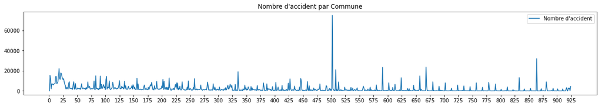

```python
plt.figure(figsize=(20,3))
plt.plot(NbrAccParCom['values'])
plt.title("Nombre d'accident par Commune")
plt.legend(["Nombre d'accident"])
plt.xticks(np.arange(0,950,25))
plt.show()
```

### Is the number of accidents per year decreasing ?

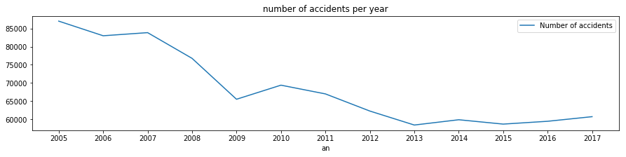

```python
#dfunique.groupby(['an']).size().plot.bar( align='center',color='deepskyblue')
NbrAccParAn = dfunique.groupby(['an']).agg('count')
NbrAccParAn['com'].plot(title="number of accidents per year",figsize=(15,3))
plt.legend(["Number of accidents"])
plt.xticks(np.arange(2005,2018))
plt.show()
```

### Which months have higher frequency of accidents ?

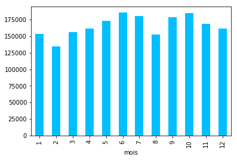

```python
df.groupby(['mois']).size().plot.bar( align='center',color='deepskyblue')
```

### Which days have higher frequency of accidents ?

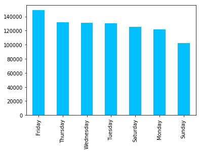

```python
week   = ['Monday','Tuesday','Wednesday','Thursday','Friday','Saturday','Sunday']
dfunique['day_of_week'].apply(lambda x:week[x]).value_counts().plot.bar( align='center',color='deepskyblue')
```

### Which Day-of-the-Month is not safe ?

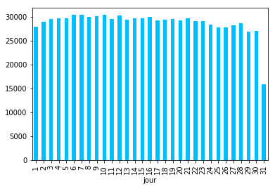

```python
dfunique.groupby(['jour']).size().plot.bar( align='center',color='deepskyblue')
```

# Which part of the day is tha safest ?

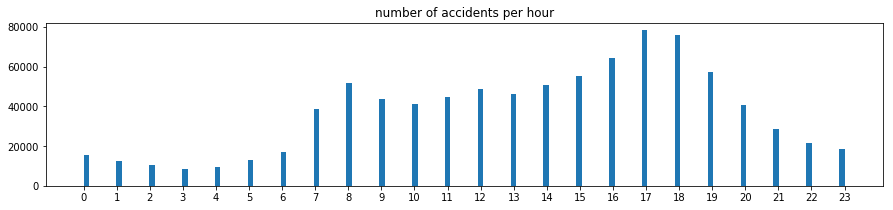

```python
plt.figure(figsize=(15,3))
plt.hist(x=dfunique['hour'],bins='auto')
plt.title("number of accidents per hour")
plt.xticks(np.arange(0,24))
plt.show()
```

### Are women worse drivers than men?

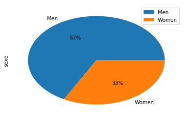

```python
df['sexe'].apply(lambda x: {1:'Men',2:'Women'}[x]).value_counts().plot.pie(autopct='%1.0f%%',legend=True)
```

### Reason for traveling at the time of the accident

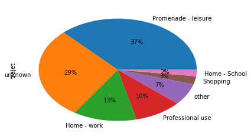

```python
df['trajet'].apply(
    lambda x: {1:'Home - work',2:'Home - School',3:'Shopping',4:'Professional use',5:'Promenade - leisure',9:'other',0:'unknown'}[x]
    ).value_counts().plot.pie(autopct='%1.0f%%')
plt.show()
```

### Category of vehicle

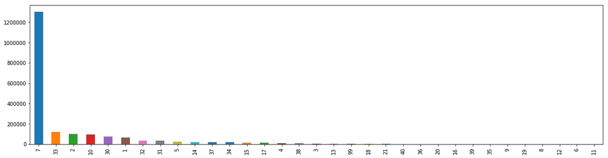

```python
df['catv'].value_counts().plot.bar(figsize=(20,5))
plt.show()
```

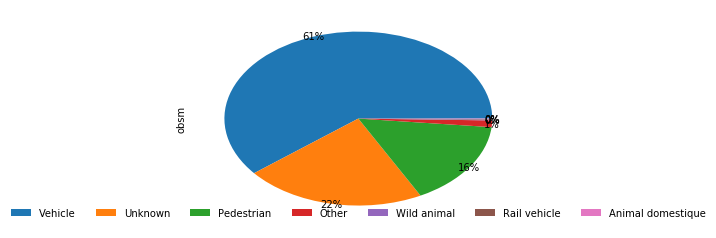

```python
df['obsm'].value_counts().plot.pie(labels=None,autopct='%1.0f%%',pctdistance =1)
plt.legend(["Vehicle","Unknown","Pedestrian","Other","Wild animal","Rail vehicle","Animal domestique"],frameon=False,ncol=7, loc='lower center')
plt.show()
```

### User category

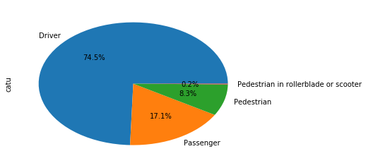

```python
df['catu'].apply(
    lambda x: {1:'Driver',2:'Passenger',3:'Pedestrian',4:'Pedestrian in rollerblade or scooter'}[x]
    ).value_counts().plot.pie(autopct='%1.1f%%')
```

### lighting conditions in which the accident occurred

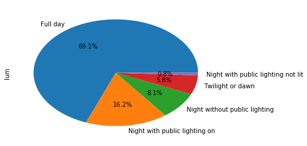

```python
df['lum'].apply(
    lambda x: {1:'Full day',
2:'Twilight or dawn',
3:'Night without public lighting',
4:'Night with public lighting not lit',
5:'Night with public lighting on'}[x]
    ).value_counts().plot.pie(autopct='%1.1f%%')
```

### Type of Intersection

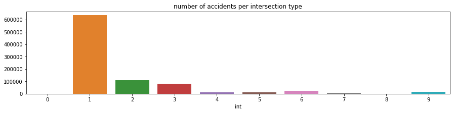

```python
data_1 = dfunique.groupby(by='int', as_index=False).count()
plt.figure(figsize=(15,3))
sns.barplot(x='int',y='com',data=data_1)
plt.title("number of accidents per intersection type")
plt.ylabel("")
plt.show()
```

### Age of users

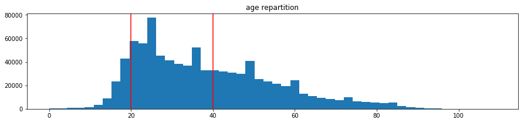

```python
plt.figure(figsize=(15,3))
plt.hist(x=dfunique['age'],bins=50)
plt.title("age repartition")
plt.axvline(x=20, color='r', linestyle='-')
plt.axvline(x=40, color='r', linestyle='-')
plt.show()
```

### Accident gravity

```python
dfGraviteCategorieUsager = df.pivot_table(index='grav',columns='catu',values='Unnamed: 0', aggfunc='count')
```

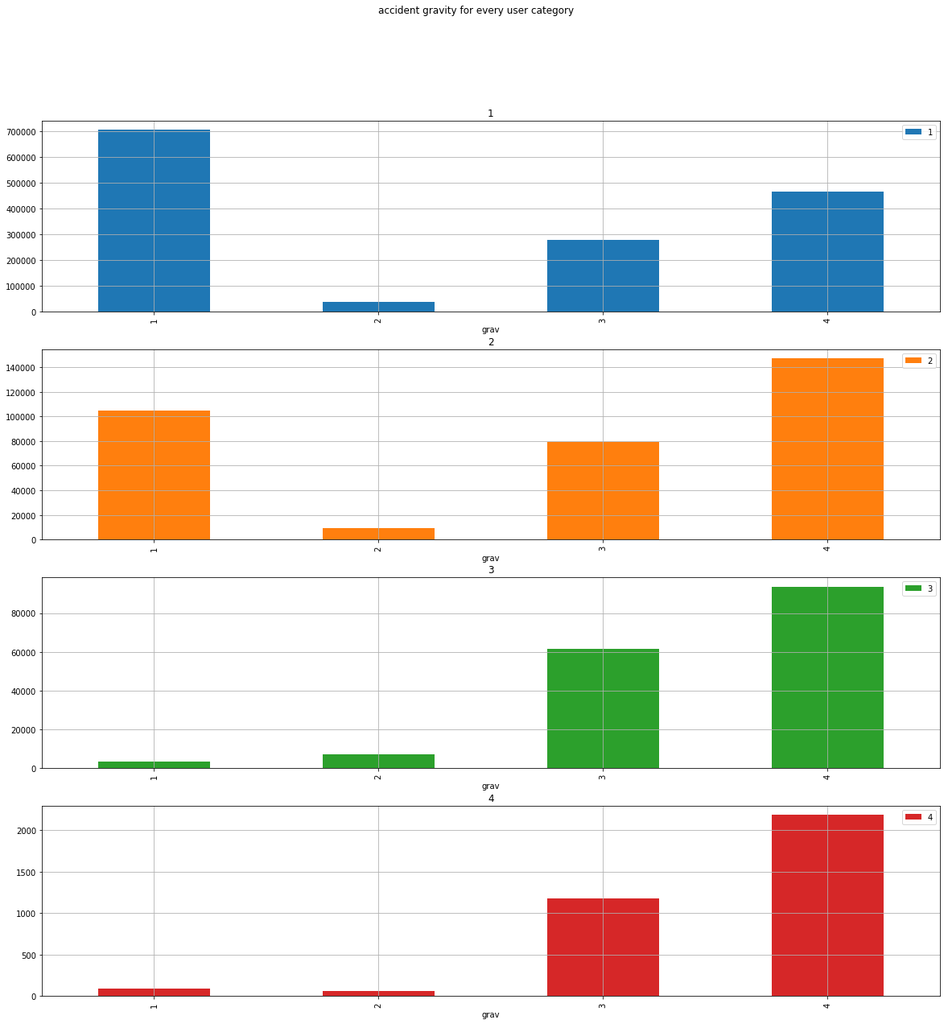

```python
dfGraviteCategorieUsager.plot(subplots=True,
                             figsize=(20,20),
                             kind='bar',
                             grid=True,
                             title="accident gravity for every user category",
                             legend=True,sharex=False)

plt.show()
```

```python
len(df[(df['catu']==3)|(df['catu']==4)])/len(df)
```

```
0.08476335059294134
```

```python
dfGraviteTrajet = df.pivot_table(index='lum',columns='trajet',values='Unnamed: 0', aggfunc='count')
```

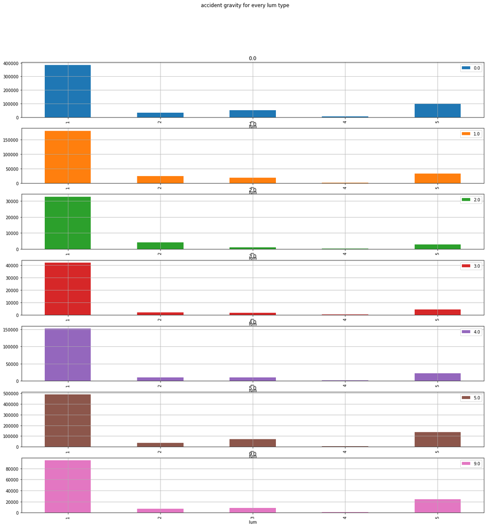

```python
dfGraviteTrajet.plot(subplots=True,
                             figsize=(20,20),
                             kind='bar',
                             grid=True,
                             title="accident gravity for every lum type",
                             legend=True,sharex=False)
plt.show()
```

```python
dfGraviteSurface = df.pivot_table(index='lum',columns='surf',values='Unnamed: 0', aggfunc='count')
```

[figure not shown]

```python
dfGraviteSurface.plot(subplots=True,
                             figsize=(20,20),
                             kind='bar',
                             grid=True,
                             title="Nombre d'accident par surface pour chaque type de lumiere",
                             legend=True,sharex=False)
plt.show()
```

```python
dfGraviteAgg = df.pivot_table(index='lum',columns='agg',values='Unnamed: 0', aggfunc='count')
```

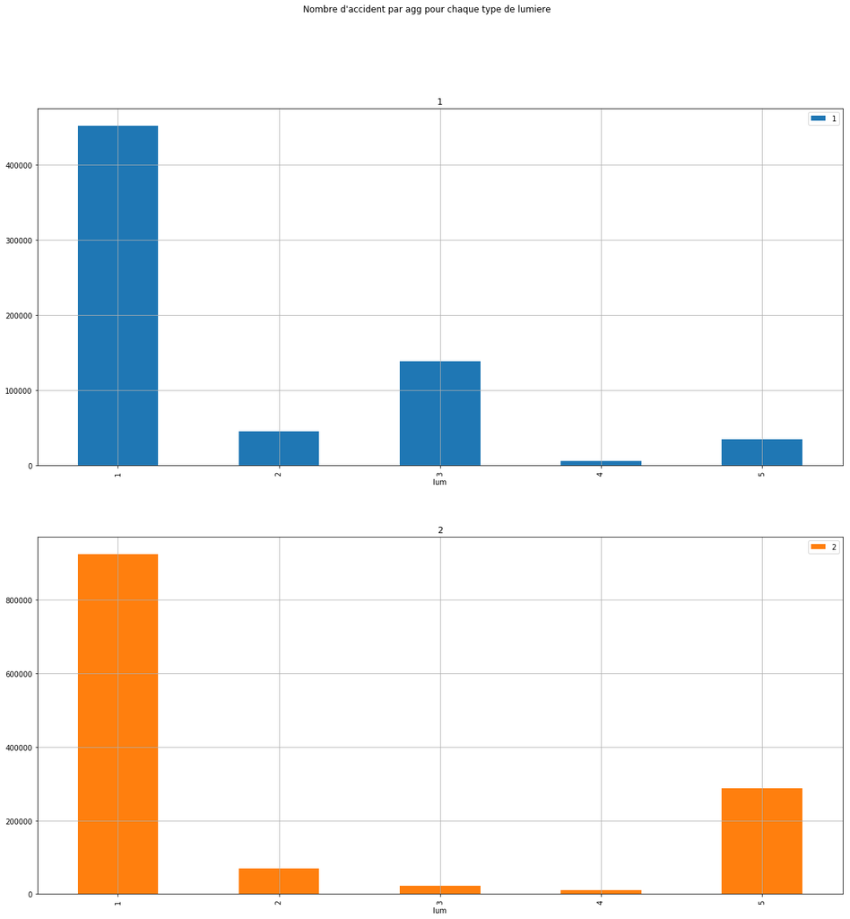

```python
dfGraviteAgg.plot(subplots=True,
                             figsize=(20,20),
                             kind='bar',
                             grid=True,
                             title="Nombre d'accident par agg pour chaque type de lumiere",
                             legend=True,sharex=False)
plt.show()
```

```python
dfGraviteInt = df.pivot_table(index='lum',columns='int',values='Unnamed: 0', aggfunc='count')
```

[figure not shown]

```python
dfGraviteInt.plot(subplots=True,
                             figsize=(20,20),
                             kind='bar',
                             grid=True,
                             title="Nombre d'accident par type d'intersection pour chaque type de lumiere",
                             legend=True,sharex=False)
plt.show()
```

```python
dfGraviteInt = df.pivot_table(index='atm',columns='int',values='Unnamed: 0', aggfunc='count')
```

[figure not shown]

```python
dfGraviteInt.plot(subplots=True,
                             figsize=(20,20),
                             kind='bar',
                             grid=True,
                             title="Nombre d'accident par type d'intersection pour chaque atmosphere",
                             legend=True,sharex=False)
plt.show()
```

```python
dfGraviteInt = df.pivot_table(index='atm',columns='col',values='Unnamed: 0', aggfunc='count')
```

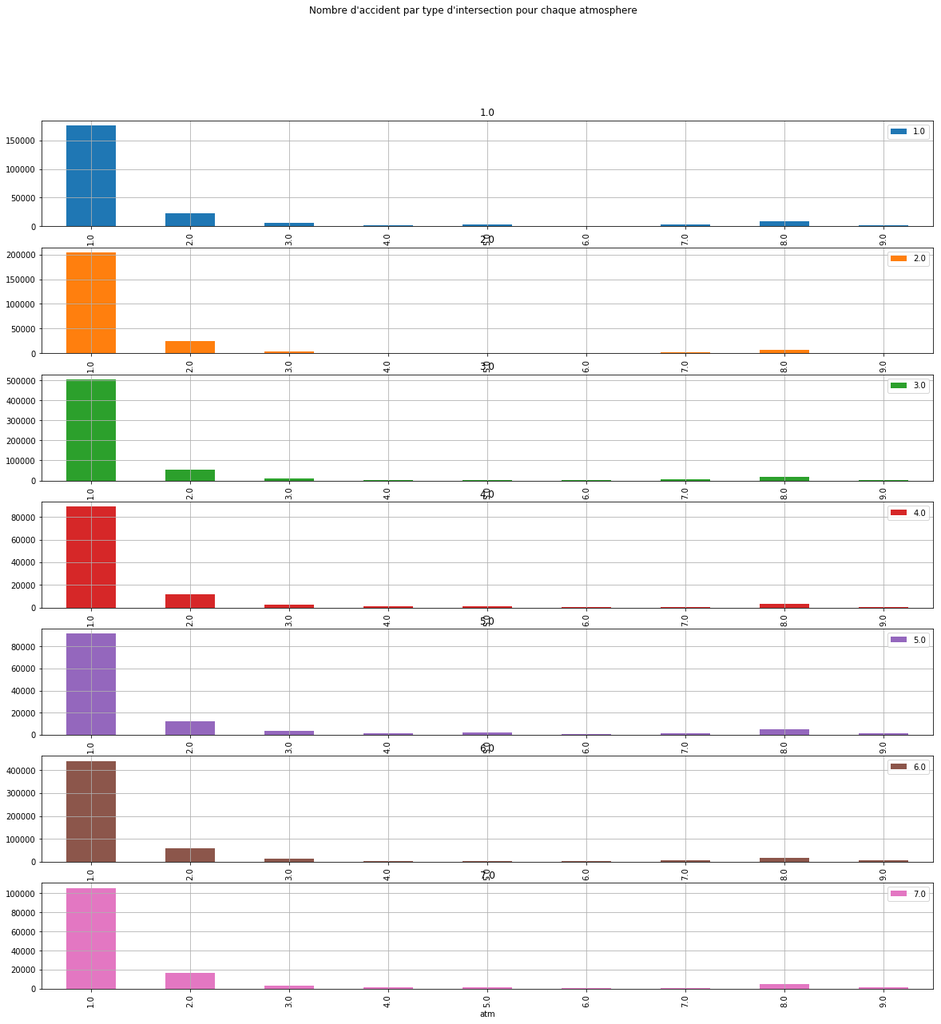

```python
dfGraviteInt.plot(subplots=True,
                             figsize=(20,20),
                             kind='bar',
                             grid=True,
                             title="Nombre d'accident par type d'intersection pour chaque atmosphere",
                             legend=True,sharex=False)
plt.show()
```

```python
dfGraviteInt = df.pivot_table(index='lum',columns='catr',values='Unnamed: 0', aggfunc='count')
```

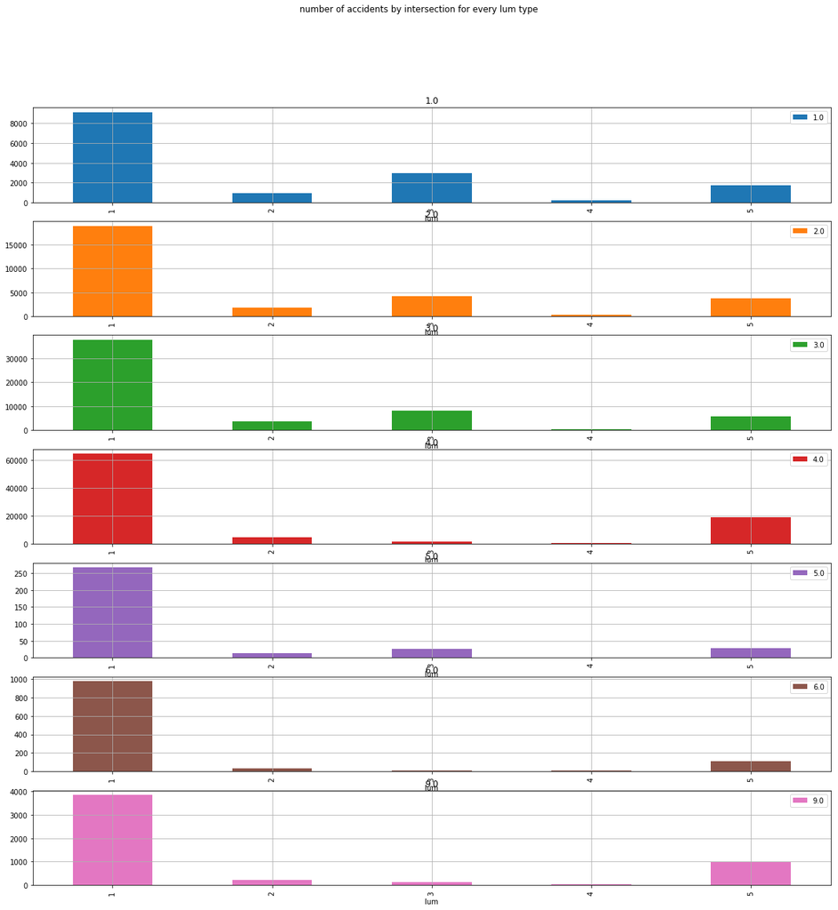

```python
dfGraviteInt.plot(subplots=True,
                             figsize=(20,20),
                             kind='bar',
                             grid=True,
                             title="number of accidents by intersection for every lum type",
                             legend=True,sharex=False)
plt.show()
```

```python
df['count'] = 1
```

```python
aggregated = df.groupby(['date','commune']).agg({'place':'mean','catu':'mean','grav':'mean','sexe':'mean','trajet':'mean','secu':'mean','locp':'mean','actp':'mean',
       'etatp':'mean','an_nais':'mean','senc':'mean','catv':'mean','occutc':'mean','obs':'mean','obsm':'mean','choc':'mean',
       'manv':'mean','catr':'mean','circ':'mean','nbv':'mean','vosp':'mean','prof':'mean','plan':'mean','lartpc':'mean',
       'larrout':'mean','surf':'mean','infra':'mean','situ':'mean','env1':'mean','an':'mean','mois':'mean','jour':'mean',
       'hrmn':'mean','lum':'mean','agg':'mean','int':'mean','atm':'mean','col':'mean','hour':'mean','min':'mean',
       'day_of_week':'mean','day_of_year':'mean','age':'mean','count':'sum'}).reset_index()
```

```python
aggregated.to_csv('aggregated.csv',low_memory=False)
```

```python
aggregated = pd.read_csv('aggregated.csv')
```

## Feature Engineering

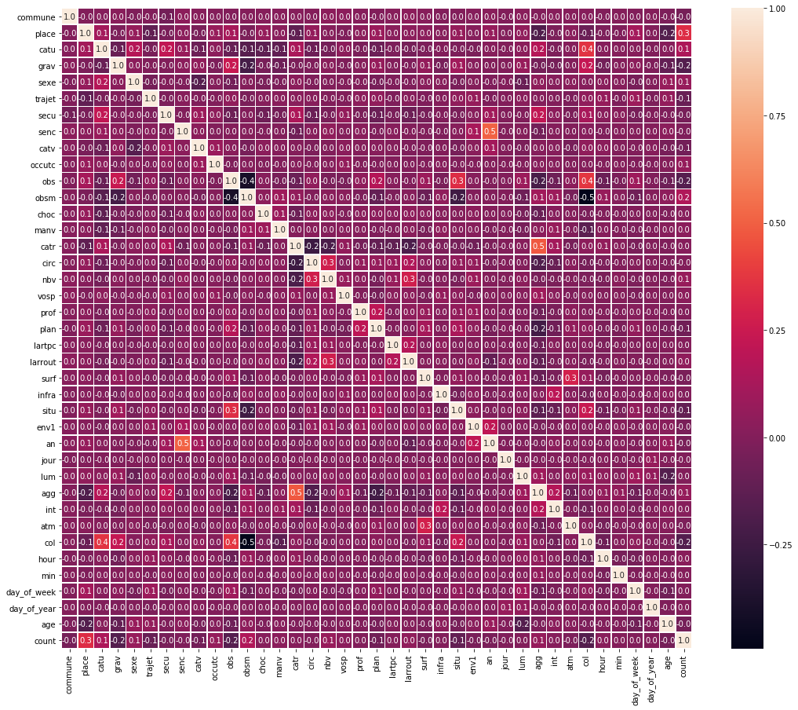

```python
f,ax = plt.subplots(figsize=(18, 15))
sns.heatmap(aggregated[aggregated.columns[0:45]].corr(), annot=True, linewidths=.5, fmt= '.1f',ax=ax)
```

According to the graph , we can see that there are some important corrolations between our variable , so we proceed to eliminate information redundancy

```python
del(aggregated["etatp"])
del(aggregated["actp"])
del(aggregated["locp"])
del(aggregated['mois'])
del(aggregated['hrmn'])
del(aggregated['an_nais'])
del(aggregated['Unnamed: 0'])
```

And so we end up with these columns

```python
aggregated.columns
```

```
Index(['date', 'commune', 'place', 'catu', 'grav', 'sexe', 'trajet', 'secu',
       'senc', 'catv', 'occutc', 'obs', 'obsm', 'choc', 'manv', 'catr', 'circ',
       'nbv', 'vosp', 'prof', 'plan', 'lartpc', 'larrout', 'surf', 'infra',
       'situ', 'env1', 'an', 'jour', 'lum', 'agg', 'int', 'atm', 'col', 'hour',
       'min', 'day_of_week', 'day_of_year', 'age', 'count'],
      dtype='object')
```

We didn't use PCA for dimentionality reduction , instead we're going to redo some feature engineering using the insights from our random forest regressor in the modeling part.

# Modeling

```python
from sklearn.preprocessing import LabelEncoder
le = LabelEncoder()
aggregated['commune'] = le.fit_transform(aggregated.commune.values)
```

```python
y = aggregated['count']
x = aggregated.drop(['count','date'], axis = 1)
```

```python
from scipy.cluster import hierarchy as hc
```

```python
from sklearn.model_selection import train_test_split
X_train, X_test, y_train, y_test = train_test_split(x, y, test_size=0.2, random_state=0)
```

```python
from sklearn.metrics import mean_squared_error
```

### Linear Model

```python
from sklearn.linear_model import LinearRegression
lm = LinearRegression()
lm.fit(X_train,y_train)
```

```
LinearRegression(copy_X=True, fit_intercept=True, n_jobs=1, normalize=False)
```

```python
lm_pred = lm.predict(X_test)
```

```python
print(mean_squared_error(lm_pred,y_test))
```

```
3.4505211889491716
```

### Random Forest Regressor

```python
from sklearn.ensemble import RandomForestRegressor
rf = RandomForestRegressor(n_estimators = 10)
rf.fit(X_train, y_train)
y_pred = rf.predict(X_test)
```

```python
rf_pref=y_pred
print(mean_squared_error(rf_pref,y_test))
```

```
0.5329058063112966
```

### Feature Engineering using random forest regressor interpretation

```python
fi = rf_feat_importance(rf, X_train); fi[:10]
```

[output not shown]

```python
def plot_fi(fi): return fi.plot('cols', 'imp', 'barh', figsize=(12,7), legend=False)
```

[figure not shown]

```python
plot_fi(fi[:30]);
```

```python
to_keep = fi[fi.imp>0.005].cols; len(to_keep)
```

```
17
```

```python
to_keep = list(to_keep)
to_keep.append('count')
```

```python
df_keep = aggregated[to_keep].copy()
```

```python
y1 = df_keep['count']
x1 = df_keep.drop(['count'], axis = 1)
```

```python
X_train1, X_test1, y_train1, y_test1 = train_test_split(x1, y1, test_size=0.2)
```

```python
rf = RandomForestRegressor()
rf.fit(X_train1, y_train1)
y_pred1 = rf.predict(X_test1)
```

```python
rf_pref1=y_pred1
print(mean_squared_error(rf_pref1,y_test1))
```

```
0.415358349248639
```

We do see a reduction in mean squared error.  
Let's plot our feature importance again :

```python
fi = rf_feat_importance(rf, X_train1);
fi = fi.drop([9]).reset_index()
fi[:10]
```

[output not shown]

[figure not shown]

```python
plot_fi(fi);
```

### Ordinary Least square prediction

```python
import statsmodels.api as sm
linReg = sm.OLS(y_train,X_train).fit()
y_pred=linReg.predict(X_test)
print('The rmse of prediction is:', mean_squared_error(y_test, y_pred) ** 0.5)
```

```
The rmse of prediction is: 1.8556457482148863
```

### Time Series prediction using fb Prophet

```python
d = aggregated[['count','date']].copy()
```

```python
d['date'] = pd.to_datetime(d['date'])
```

```python
d.columns=['y','ds']
```

```python
d = d.groupby('ds').agg('sum').reset_index()
```

```python
holidays = pd.read_csv('jours_feries.csv')
```

```python
holidays = holidays.loc[holidays['est_jour_ferie'] == True]
del holidays['est_jour_ferie']
holidays.columns=['ds','holiday']
```

```python
holidays['ds'] = pd.to_datetime(holidays['ds'])
```

```python
from fbprophet import Prophet
m = Prophet(holidays=holidays,yearly_seasonality=True , weekly_seasonality=True, daily_seasonality=False)
```

```python
m.fit(d)
```

```
<fbprophet.forecaster.Prophet at 0x1c2829c860>
```

```python
future = m.make_future_dataframe(periods=365)
future.tail()
```

|  | ds |
| --- | --- |
| 5108 | 2018-12-27 |
| 5109 | 2018-12-28 |
| 5110 | 2018-12-29 |
| 5111 | 2018-12-30 |
| 5112 | 2018-12-31 |

```python
forecast = m.predict(future)
forecast[['ds', 'yhat', 'yhat_lower', 'yhat_upper']].tail()
```

|  | ds | yhat | yhat_lower | yhat_upper |
| --- | --- | --- | --- | --- |
| 5108 | 2018-12-27 | 316.361712 | 251.607611 | 394.761899 |
| 5109 | 2018-12-28 | 376.598870 | 306.869327 | 452.023233 |
| 5110 | 2018-12-29 | 317.197830 | 243.738025 | 392.623120 |
| 5111 | 2018-12-30 | 238.072540 | 168.571101 | 311.487158 |
| 5112 | 2018-12-31 | 277.005628 | 201.940391 | 347.053785 |

```python
forecast.to_csv('forecast.csv')
```

FBProphet allowed us to predict the number of accidents in France for every day of the next year We could do the same thing for every commune .

Let's predict the accidents for a specific commune :

We chose the commune with the most accidents recorded since that would be a good point to start off at

```python
aggregated['commune'].mode()
```

```
0    13055
dtype: int64
```

```python
most = aggregated[aggregated['commune']==13055]
```

```python
p = most[['count','date']]
```

```python
p.columns=['y','ds']
```

```python
from fbprophet import Prophet
m = Prophet(holidays=holidays,yearly_seasonality=True , weekly_seasonality=True, daily_seasonality=False)
```

```python
m.fit(p)
```

```
<fbprophet.forecaster.Prophet at 0x1103ce358>
```

```python
future = m.make_future_dataframe(periods=365)
future.tail()
```

|  | ds |
| --- | --- |
| 5041 | 2018-12-27 |
| 5042 | 2018-12-28 |
| 5043 | 2018-12-29 |
| 5044 | 2018-12-30 |
| 5045 | 2018-12-31 |

```python
forecast = m.predict(future)
forecast[['ds', 'yhat', 'yhat_lower', 'yhat_upper']].tail()
```

|  | ds | yhat | yhat_lower | yhat_upper |
| --- | --- | --- | --- | --- |
| 5041 | 2018-12-27 | 13.151239 | 4.398257 | 21.579152 |
| 5042 | 2018-12-28 | 13.480971 | 4.855262 | 22.308776 |
| 5043 | 2018-12-29 | 9.596897 | 1.372220 | 18.032090 |
| 5044 | 2018-12-30 | 7.205354 | -1.148771 | 15.148501 |
| 5045 | 2018-12-31 | 11.652949 | 3.516416 | 20.924851 |

```python
forecast.to_csv('forecast-13055.csv')
```

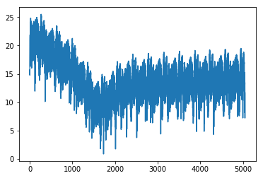

```python
forecast.yhat.plot()
```

# Deployment

Let's export our models

```python
import pickle
with open('prophet.pkl', 'wb') as f:
    pickle.dump(m, f)
```

## Let's prepare the data for our dashboard

```python
f = pd.read_csv('forecast.csv')
```

```python
f = f[['yhat','ds']]
```

```python
f['ds'] = pd.to_datetime(f['ds'])
```

```python
f['ds'] =f['ds'].dt.month
```

```python
f['ds'] = f.ds.apply(lambda x:[
        "JAN",
        "FEB",
        "MAR",
        "APR",
        "MAY",
        "JUN",
        "JUL",
        "AUG",
        "SEP",
        "OCT",
        "NOV",
        "DEC"
      ][x-1])
```

```python
f = f.groupby(['ds']).agg({'yhat':'sum'}).reset_index()
```

```python
f.yhat = f.yhat.apply(lambda x:int(x))
```

```python
f.head()
```

|  | ds | yhat |
| --- | --- | --- |
| 0 | APR | 171907 |
| 1 | AUG | 163202 |
| 2 | DEC | 173785 |
| 3 | FEB | 142562 |
| 4 | JAN | 162751 |

```python
print(list(f.yhat))
```

```
[171907, 163202, 173785, 142562, 162751, 192426, 199669, 167030, 184742, 181333, 197704, 191183]
```

```python
sum([171907, 163202, 173785, 142562, 162751, 192426, 199669, 167030, 184742, 181333, 197704, 191183])
```

```
2128294
```

### Data for most dangerous day of the week

```python
list(dfunique['day_of_week'].value_counts().sort_index().values)
```

[output not shown]

### Data for accidents in 2017

```python
aggregated = pd.read_csv('aggregated.csv',low_memory=False)
```

```python
c = aggregated[['date','count','an']].copy()
```

```python
c = c[c['an'] == 2017].drop(['an'],axis=1)
```

```python
c['date'] = pd.to_datetime(c['date'])
```

```python
c['date'] =c['date'].dt.month
```

```python
c = c.groupby(['date']).agg({'count':'sum'}).reset_index()
```

```python
np.array(list(c['count']))
```

```
array([10041,  9039, 11326, 11634, 11720, 13231, 12428, 10137, 11584, 12284, 11571, 11026])
```

### Let's get the data for "fatal" chart

```python
df = pd.read_csv('accidents.csv',low_memory=False)
```

```python
x = df[(df['an'] == 2017) & (df['grav']== 2)]
```

```python
x = x[['date']]
```

```python
x['count']=1
```

```python
x['date'] = pd.to_datetime(x['date'])
x['date'] = x['date'].dt.month
x = x.groupby(['date']).agg({'count':'sum'}).reset_index()
```

```python
np.array(list(x['count']))
```

```
array([268, 214, 285, 293, 308, 333, 366, 310, 306, 328, 285, 304])
```

### Let's get the data for "other" chart

```python
np.array(list(c['count'])) - np.array(list(x['count']))
```

```
array([ 9773,  8825, 11041, 11341, 11412, 12898, 12062,  9827, 11278, 11956, 11286, 10722])
```

# Conclusion

First our modelling has provided us with some good insight over what makes the number of accidents go up

So where you live actually impacts your chance of being in an accident

Then we provided a proof of concept for a predicting solution of the number of accidents , that can be used to determine how much stuff is needed on special days and if the ambulances should be on alert state.